# Assignment4_JianghongMan

Jianghong Man

4/26/2021

0. Set the working directory and load the libary

```r
setwd('~/Desktop/Time_Series/4/Traffic_Flow_Data/')
library(fpp)
```

```r
library(ggplot2)
library(dplyr)
library(TSA)
library(readxl)
```

For this assignment, I will use a hourly traffic flow datasets from Illinois Department of Transpiration (IDOT) for I80E 1EXIT for 6/16/2013 − 7/1/2013.

1. Combine the data from the 16 files into a single dataset and plot it.

```r
# Load the data
June_16 <- read_excel('I-57-2013-June-16.xls')
```

[output not shown]

```r
June_17 <- read_excel('I-57-2013-June-17.xls')
```

[output not shown]

```r
June_18 <- read_excel('I-57-2013-June-18.xls')
```

[output not shown]

```r
June_19 <- read_excel('I-57-2013-June-19.xls')
```

[output not shown]

```r
June_20 <- read_excel('I-57-2013-June-20.xls')
```

[output not shown]

```r
June_21 <- read_excel('I-57-2013-June-21.xls')
```

[output not shown]

```r
June_22 <- read_excel('I-57-2013-June-22.xls')
```

[output not shown]

```r
June_23 <- read_excel('I-57-2013-June-23.xls')
```

[output not shown]

```r
June_24 <- read_excel('I-57-2013-June-24.xls')
```

[output not shown]

```r
June_25 <- read_excel('I-57-2013-June-25.xls')
```

[output not shown]

```r
June_26 <- read_excel('I-57-2013-June-26.xls')
```

[output not shown]

```r
June_27 <- read_excel('I-57-2013-June-27.xls')
```

[output not shown]

```r
June_28 <- read_excel('I-57-2013-June-28.xls')
```

[output not shown]

```r
June_29 <- read_excel('I-57-2013-June-29.xls')
```

[output not shown]

```r
June_30 <- read_excel('I-57-2013-June-30.xls')
```

[output not shown]

```r
July_1 <- read_excel('I-57-2013-July-1.xls')
```

[output not shown]

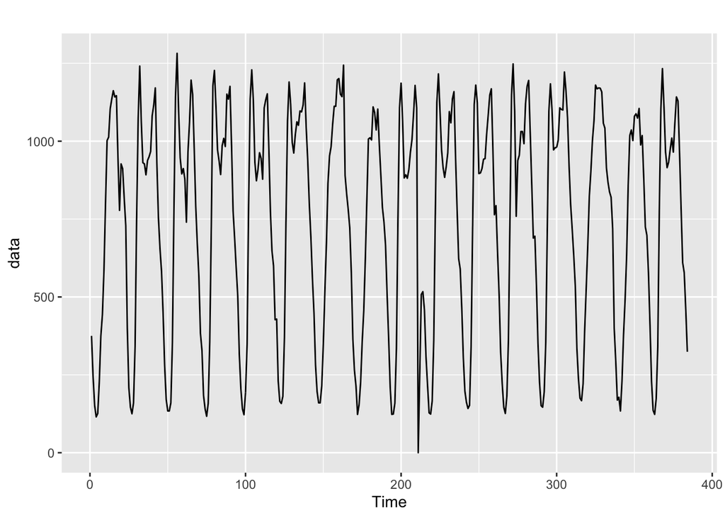

```r
J16 <- as.data.frame(June_16[5:28,5])
J17 <- as.data.frame(June_17[5:28,5])
J18 <- as.data.frame(June_18[5:28,5])
J19 <- as.data.frame(June_19[5:28,5])
J20 <- as.data.frame(June_20[5:28,5])
J21 <- as.data.frame(June_21[5:28,5])
J22 <- as.data.frame(June_22[5:28,5])
J23 <- as.data.frame(June_23[5:28,5])
J24 <- as.data.frame(June_24[5:28,5])
J25 <- as.data.frame(June_25[5:28,5])
J26 <- as.data.frame(June_26[5:28,5])
J27 <- as.data.frame(June_27[5:28,5])
J28 <- as.data.frame(June_28[5:28,5])
J29 <- as.data.frame(June_29[5:28,5])
J30 <- as.data.frame(June_30[5:28,5])
J01 <- as.data.frame(July_1[5:28,5])

# Combine the data
data <- ts(rbind(J16,J17,J18,J19,J20,J21,J22,J23,J24,J25,J26,J27,J28,J29,J30,J01))

# Plot the data
autoplot(data)
```

2. Split the dataset into a training dataset which includes 6/16/2013 - 6/30/2013 samples and a test dataset which includes 7/1/2013 samples and plot the ACF and PACF.

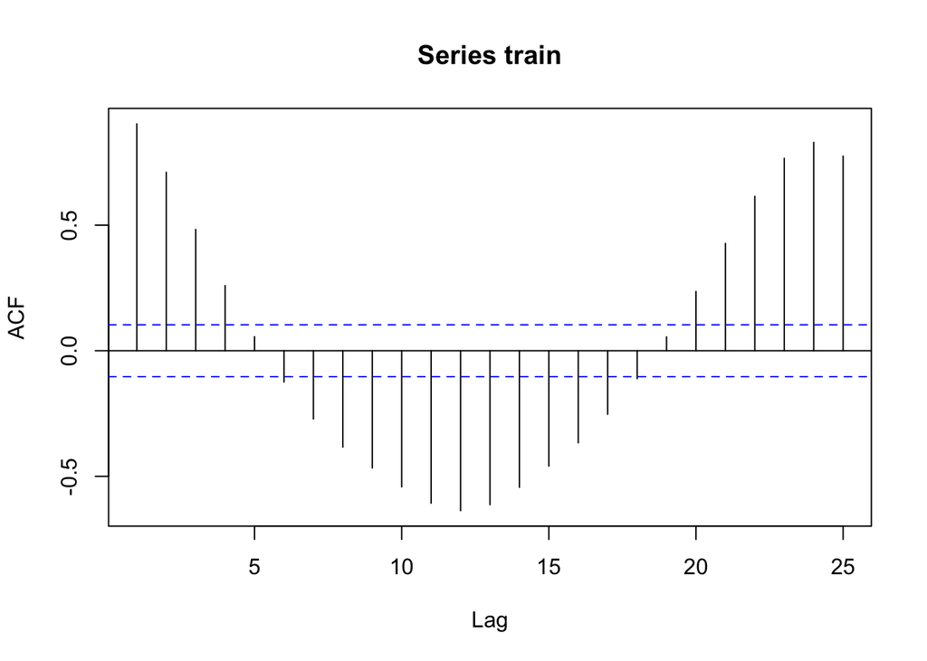

```r
train <- data[1:360,]
test <- data[361:384,]

acf(train)
```

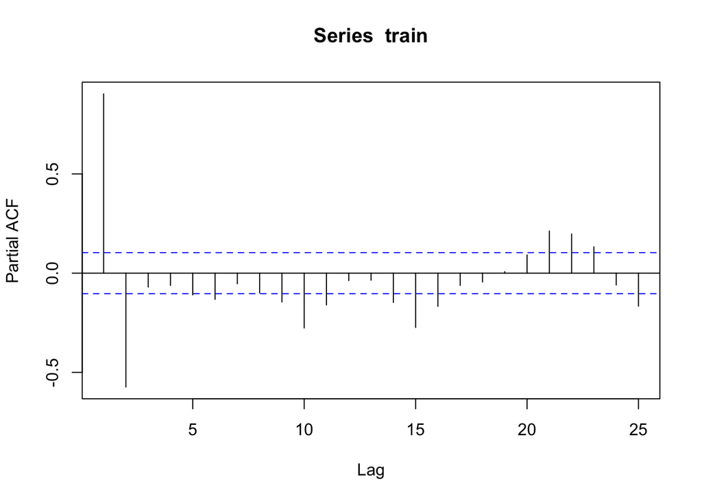

```r
pacf(train)
```

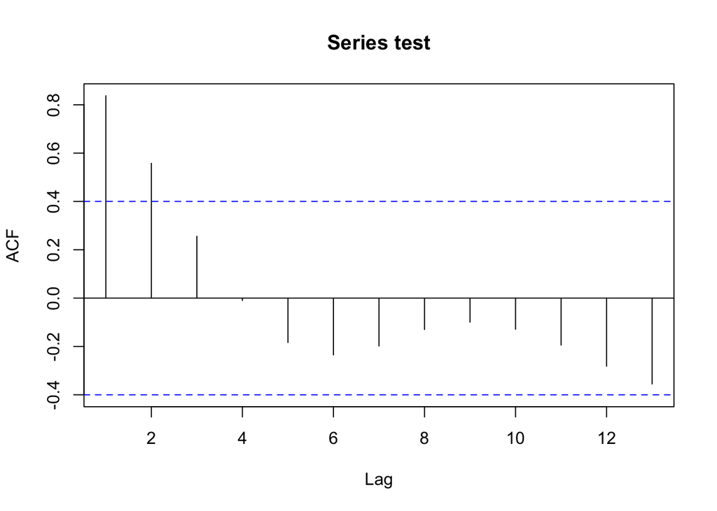

```r
acf(test)
```

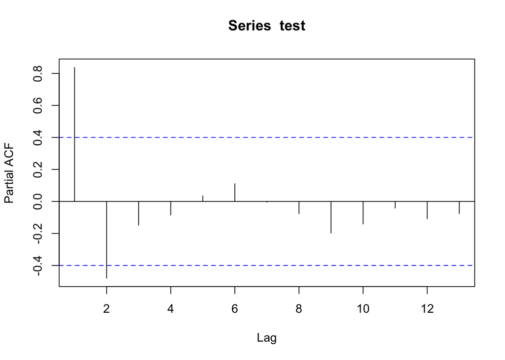

```r
pacf(test)
```

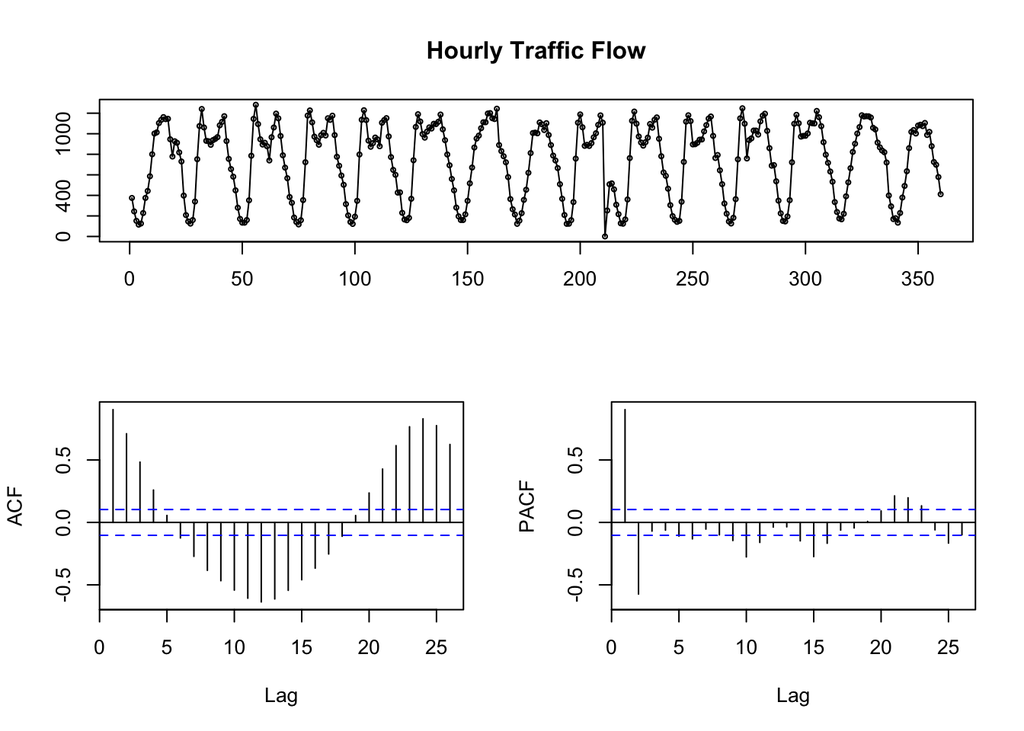

```r
tsdisplay(train,main='Hourly Traffic Flow')
```

3. Build an 𝐴𝑅𝐼𝑀𝐴(𝑝,𝑑,𝑞) model using the training dataset and R auto.arima() function. Change the values of 𝑝 and 𝑞 and determine the best model using AICc and BIC values. Do AICc and BIC select the same model as the best model? For each derived model, review the residual plots for the residuals ACF and normality.

```r
fit <- auto.arima(train,trace=TRUE)
```

```
##
##  Fitting models using approximations to speed things up...
##
##  ARIMA(2,0,2) with non-zero mean : 4451.597
##  ARIMA(0,0,0) with non-zero mean : 5263.162
##  ARIMA(1,0,0) with non-zero mean : 4647.105
##  ARIMA(0,0,1) with non-zero mean : 4888.443
##  ARIMA(0,0,0) with zero mean     : 5858.997
##  ARIMA(1,0,2) with non-zero mean : 4516.808
##  ARIMA(2,0,1) with non-zero mean : 4495.758
##  ARIMA(3,0,2) with non-zero mean : 4453.461
##  ARIMA(2,0,3) with non-zero mean : 4450.838
##  ARIMA(1,0,3) with non-zero mean : 4510.357
##  ARIMA(3,0,3) with non-zero mean : 4453.807
##  ARIMA(2,0,4) with non-zero mean : 4450.888
##  ARIMA(1,0,4) with non-zero mean : 4512.163
##  ARIMA(3,0,4) with non-zero mean : 4455.568
##  ARIMA(2,0,3) with zero mean     : 4546.084
##
##  Now re-fitting the best model(s) without approximations...
##
##  ARIMA(2,0,3) with non-zero mean : 4455.881
##
##  Best model: ARIMA(2,0,3) with non-zero mean
```

```r
fit # AICc=4455.88
```

```
## Series: train
## ARIMA(2,0,3) with non-zero mean
##
## Coefficients:
##          ar1      ar2      ma1      ma2      ma3      mean
##       1.8088  -0.8853  -0.5348  -0.2671  -0.1157  746.3181
## s.e.  0.0288   0.0287   0.0600   0.0596   0.0654    6.8586
##
## sigma^2 estimated as 13443:  log likelihood=-2220.78
## AIC=4455.56   AICc=4455.88   BIC=4482.77
```

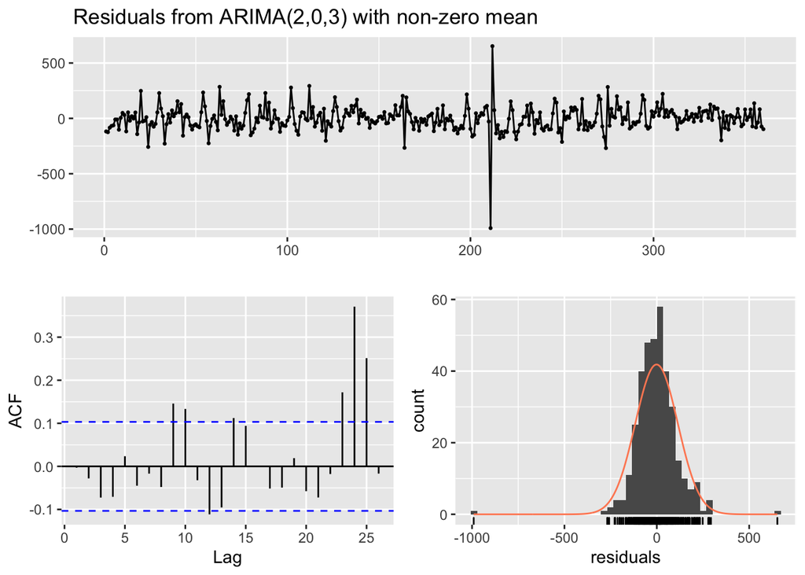

```
##
##  Ljung-Box test
##
## data:  Residuals from ARIMA(2,0,3) with non-zero mean
## Q* = 20.439, df = 4, p-value = 0.0004089
##
## Model df: 6.   Total lags used: 10
```

```r
checkresiduals(fit)
```

```r
shapiro.test(fit$residuals)
```

```
##
##  Shapiro-Wilk normality test
##
## data:  fit$residuals
## W = 0.87428, p-value < 2.2e-16
```

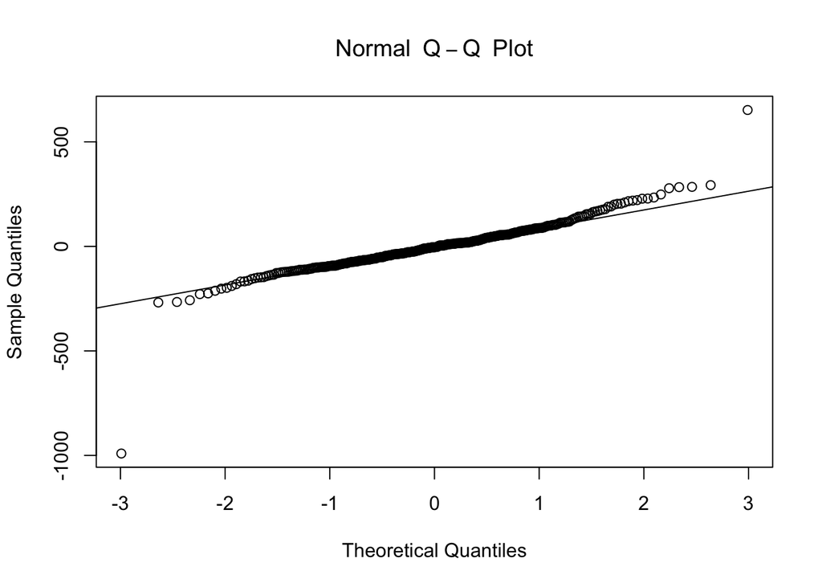

```r
qqnorm(fit$residuals,main=expression(Normal~~Q-Q~~Plot))
qqline(fit$residuals)
```

```r
eacf(train)
```

```
## AR/MA
##   0 1 2 3 4 5 6 7 8 9 10 11 12 13
## 0 x x x x o x x x x x x  x  x  x
## 1 x x x x o x x x o o x  x  x  x
## 2 o o x o o o o x x o o  x  x  x
## 3 x o o x o o o o o o o  o  x  o
## 4 x x o x o o o o o o o  o  o  o
## 5 x x x o o o o o o o o  o  o  o
## 6 x x x x o o o o o o o  o  o  o
## 7 x x o x x o o o o x o  o  o  o
```

```r
fit.1 <- train %>% Arima(order = c(0, 1, 2))
summary(fit.1) # AICc=4537.04
```

```
## Series: .
## ARIMA(0,1,2)
##
## Coefficients:
##          ma1     ma2
##       0.5435  0.2399
## s.e.  0.0499  0.0519
##
## sigma^2 estimated as 17816:  log likelihood=-2265.49
## AIC=4536.97   AICc=4537.04   BIC=4548.62
##
## Training set error measures:
##                       ME     RMSE      MAE  MPE MAPE      MASE       ACF1
## Training set -0.09849781 132.9208 88.64589 -Inf  Inf 0.7883441 0.01434807
```

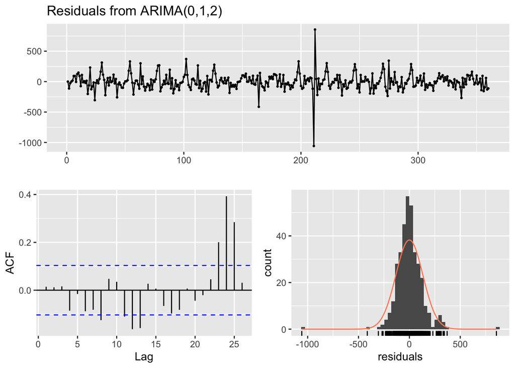

```
##
##  Ljung-Box test
##
## data:  Residuals from ARIMA(0,1,2)
## Q* = 15.394, df = 8, p-value = 0.05192
##
## Model df: 2.   Total lags used: 10
```

```r
checkresiduals(fit.1)
```

```r
fit.2 <- train %>% Arima(order = c(1, 0, 2))
summary(fit.2) # AICc=4517.94
```

```
## Series: .
## ARIMA(1,0,2) with non-zero mean
##
## Coefficients:
##          ar1     ma1     ma2      mean
##       0.7863  0.6155  0.3036  734.0936
## s.e.  0.0371  0.0542  0.0519   59.0842
##
## sigma^2 estimated as 16125:  log likelihood=-2253.88
## AIC=4517.77   AICc=4517.94   BIC=4537.2
##
## Training set error measures:
##                     ME     RMSE     MAE  MPE MAPE     MASE       ACF1
## Training set 0.6507962 126.2755 87.8022 -Inf  Inf 0.780841 0.04254222
```

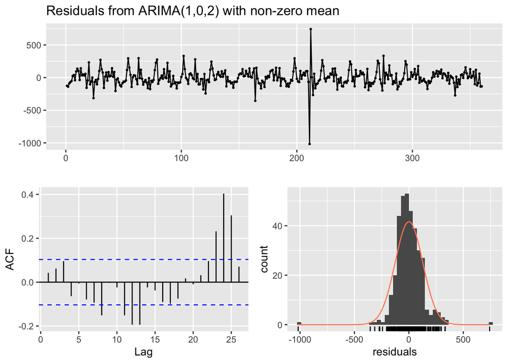

```
##
##  Ljung-Box test
##
## data:  Residuals from ARIMA(1,0,2) with non-zero mean
## Q* = 21.142, df = 6, p-value = 0.00173
##
## Model df: 4.   Total lags used: 10
```

```r
checkresiduals(fit.2)
```

```r
fit.3 <- train %>% Arima(order = c(1, 0, 3))
summary(fit.3) # AICc=4510.96
```

```
## Series: .
## ARIMA(1,0,3) with non-zero mean
##
## Coefficients:
##          ar1     ma1     ma2     ma3      mean
##       0.7131  0.7151  0.4540  0.1921  735.2137
## s.e.  0.0529  0.0686  0.0782  0.0644   53.5991
##
## sigma^2 estimated as 15765:  log likelihood=-2249.36
## AIC=4510.72   AICc=4510.96   BIC=4534.03
##
## Training set error measures:
##                     ME     RMSE      MAE  MPE MAPE      MASE        ACF1
## Training set 0.5999003 124.6846 86.17942 -Inf  Inf 0.7664093 0.008679949
```

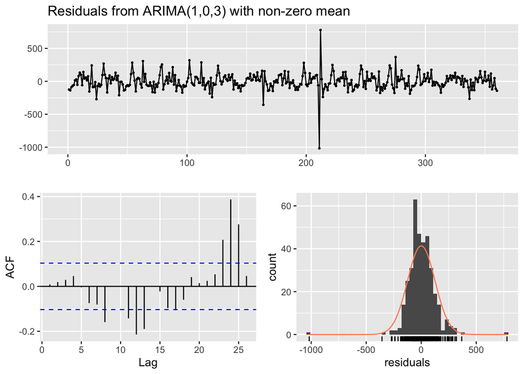

```
##
##  Ljung-Box test
##
## data:  Residuals from ARIMA(1,0,3) with non-zero mean
## Q* = 15.073, df = 5, p-value = 0.01005
##
## Model df: 5.   Total lags used: 10
```

```r
checkresiduals(fit.3)
```

```r
fit.4 <- train %>% Arima(order = c(2, 2, 3))
summary(fit.4) # AICc=4490.18
```

```
## Series: .
## ARIMA(2,2,3)
##
## Coefficients:
##          ar1      ar2      ma1     ma2      ma3
##       1.5086  -0.6460  -2.0927  1.1867  -0.0936
## s.e.  0.0684   0.0642   0.0895  0.1780   0.0890
##
## sigma^2 estimated as 15484:  log likelihood=-2238.97
## AIC=4489.94   AICc=4490.18   BIC=4513.23
##
## Training set error measures:
##                     ME     RMSE      MAE  MPE MAPE      MASE         ACF1
## Training set -2.756676 123.2175 85.07459 -Inf  Inf 0.7565838 -0.006408133
```

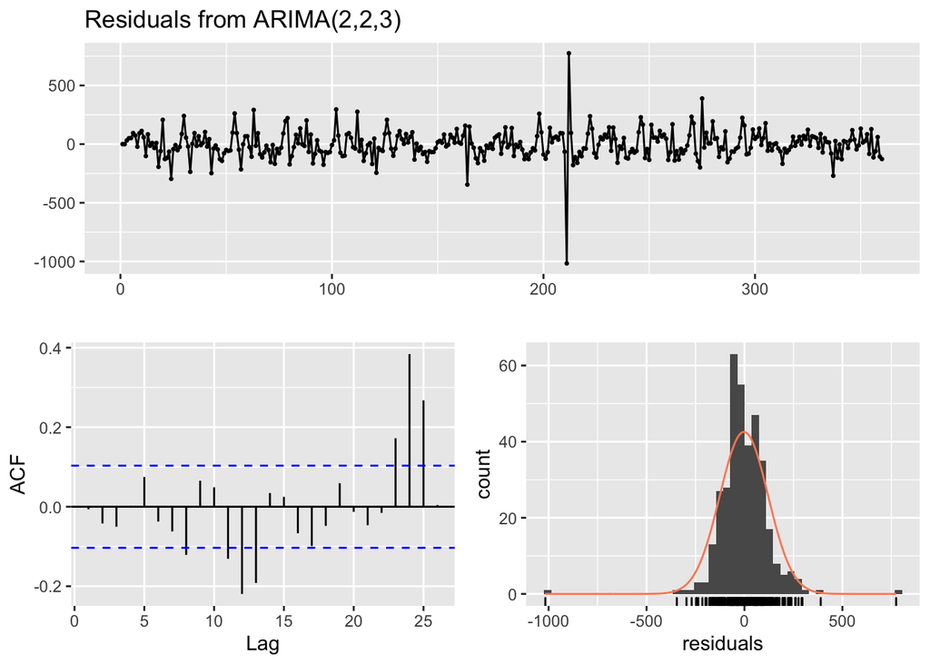

```
##
##  Ljung-Box test
##
## data:  Residuals from ARIMA(2,2,3)
## Q* = 13.474, df = 5, p-value = 0.01932
##
## Model df: 5.   Total lags used: 10
```

```r
checkresiduals(fit.4)
```

```r
fit.5 <- train %>% Arima(order = c(3, 1, 2))
summary(fit.5) # AICc=4441.69
```

```
## Series: .
## ARIMA(3,1,2)
##
## Coefficients:
##          ar1      ar2     ar3      ma1     ma2
##       2.1901  -1.5681  0.3290  -1.9887  0.9951
## s.e.  0.0512   0.0972  0.0513   0.0295  0.0302
##
## sigma^2 estimated as 13210:  log likelihood=-2214.72
## AIC=4441.45   AICc=4441.69   BIC=4464.75
##
## Training set error measures:
##                     ME     RMSE      MAE  MPE MAPE      MASE       ACF1
## Training set 0.8345444 113.9748 79.15105 -Inf  Inf 0.7039047 0.04429979
```

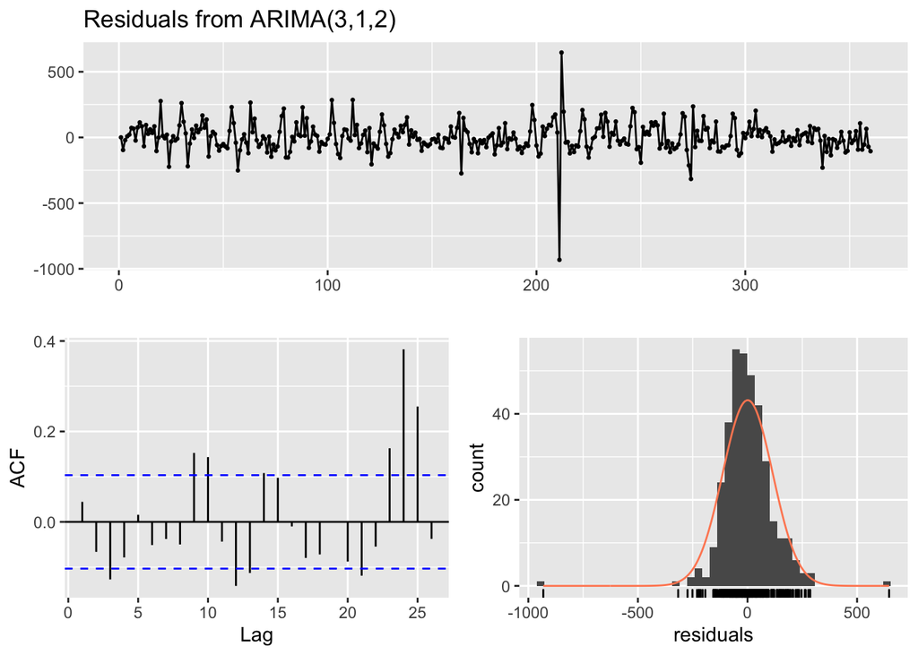

```
##
##  Ljung-Box test
##
## data:  Residuals from ARIMA(3,1,2)
## Q* = 29.285, df = 5, p-value = 2.039e-05
##
## Model df: 5.   Total lags used: 10
```

```r
checkresiduals(fit.5)
```

```r
shapiro.test(fit.5$residuals)
```

```
##
##  Shapiro-Wilk normality test
##
## data:  fit.5$residuals
## W = 0.88557, p-value = 9.623e-16
```

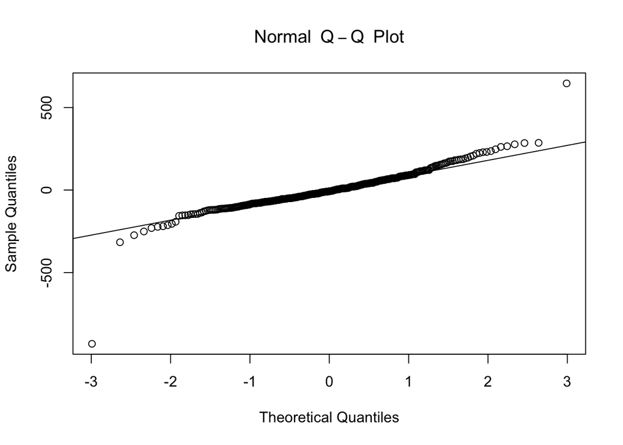

```r
qqnorm(fit.5$residuals,main=expression(Normal~~Q-Q~~Plot))
qqline(fit.5$residuals)
```

The auto-chosen model is “ARIMA(2,0,3) with non-zero mean” with the AICc 4455.88. However, after manipulating the parameters, especially changing the d value, I found that ARIMA(3,1,2) will provide a lower AICc, 4441.69. But when sticking with d=0, the arima(2,0,3) model is the best so far.

4. Build a day of the week seasonal 𝐴𝑅𝐼𝑀𝐴(𝑝,𝑑,𝑞)(𝑃,𝑄,𝐷)𝑠 model using the training dataset and R auto.arima() function.

```r
dayofweek = ts(train,frequency=1*24*7)
```

```r
fit_dayofweek <- auto.arima(dayofweek)
fit_dayofweek #AICc=2249.44
```

```
## Series: dayofweek
## ARIMA(0,1,2)(0,1,0)[168]
##
## Coefficients:
##           ma1      ma2
##       -0.4741  -0.4853
## s.e.   0.0593   0.0586
##
## sigma^2 estimated as 7081:  log likelihood=-1121.66
## AIC=2249.31   AICc=2249.44   BIC=2259.07
```

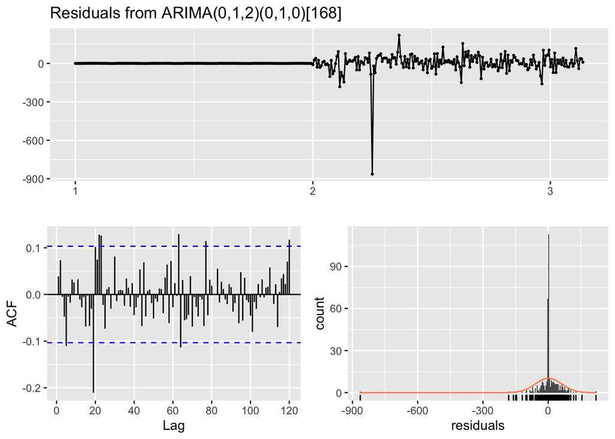

```
##
##  Ljung-Box test
##
## data:  Residuals from ARIMA(0,1,2)(0,1,0)[168]
## Q* = 91.812, df = 70, p-value = 0.04131
##
## Model df: 2.   Total lags used: 72
```

```r
checkresiduals(fit_dayofweek)
```

```r
shapiro.test(fit_dayofweek$residuals)
```

```
##
##  Shapiro-Wilk normality test
##
## data:  fit_dayofweek$residuals
## W = 0.51585, p-value < 2.2e-16
```

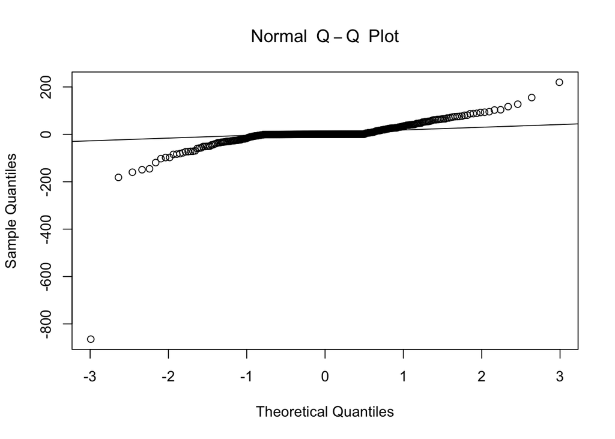

```r
qqnorm(fit_dayofweek$residuals,main=expression(Normal~~Q-Q~~Plot))
qqline(fit_dayofweek$residuals)
```

5. Use the 𝐴𝑅𝐼𝑀𝐴(𝑝,𝑑,𝑞)(𝑃,𝑄,𝐷)𝑠 model from Question 4 to forecast for July 1st (which is a Monday). Plot your result.

```r
predict_J01_dayofweek <- forecast((fit_dayofweek), h = 24)
predict_J01_dayofweek
```

```
##          Point Forecast      Lo 80     Hi 80       Lo 95     Hi 95
## 3.142857      231.35419  123.51099  339.1974   66.422255  396.2861
## 3.148810      140.97855   19.13187  262.8252  -45.369876  327.3270
## 3.154762      141.97855   20.05314  263.9040  -44.490283  328.4474
## 3.160714      176.97855   54.97446  298.9827   -9.610612  363.5677
## 3.166667      352.97855  230.89583  475.0613  166.269136  539.6880
## 3.172619      775.97855  653.81725  898.1399  589.148962  962.8081
## 3.178571     1125.97855 1003.73872 1248.2184  939.028865 1312.9282
## 3.184524     1205.97855 1083.66025 1328.2969 1018.908845 1393.0483
## 3.190476     1080.97855  958.58182 1203.3753  893.788902 1268.1682
## 3.196429      899.97855  777.50344 1022.4537  712.669036 1087.2881
## 3.202381      909.97855  787.42512 1032.5320  722.549246 1097.4079
## 3.208333      898.97855  776.34684 1021.6103  711.429533 1086.5276
## 3.214286      926.97855  804.26862 1049.6885  739.309897 1114.6472
## 3.220238      982.97855  860.19044 1105.7667  795.190336 1170.7668
## 3.226190     1022.97855  900.11231 1145.8448  835.070852 1210.8863
## 3.232143     1104.97855  982.03424 1227.9229  916.951443 1293.0057
## 3.238095     1196.97855 1073.95621 1320.0009 1008.832111 1385.1250
## 3.244048     1125.97855 1002.87823 1249.0789  937.712854 1314.2443
## 3.250000       17.97855 -105.19970  141.1568 -170.406328  206.3634
## 3.255952      270.97855  147.72242  394.2347   82.474566  459.4825
## 3.261905      525.97855  402.64459  649.3125  337.355535  714.6016
## 3.267857      534.97855  411.56681  658.3903  346.236579  723.7205
## 3.273810      476.97855  353.48908  600.4680  288.117698  665.8394
## 3.279762      326.97855  203.41140  450.5457  137.998892  515.9582
```

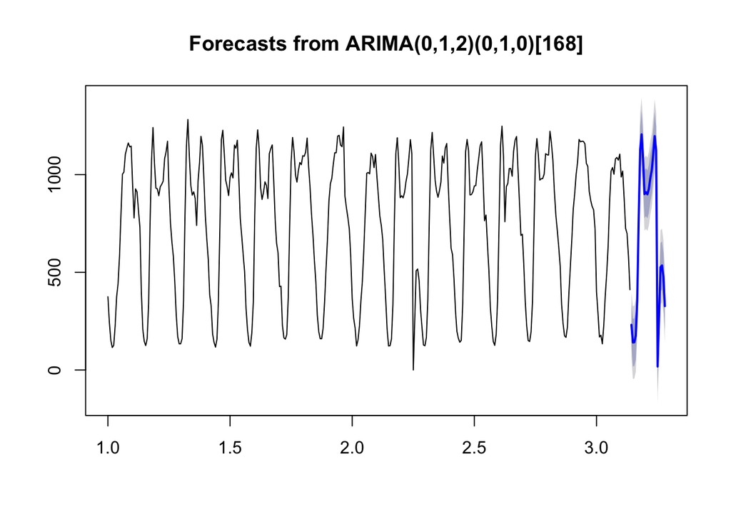

```r
plot(forecast(predict_J01_dayofweek,h=24))
```

6. Build a hour of the day seasonal 𝐴𝑅𝐼𝑀𝐴(𝑝,𝑑,𝑞)(𝑃,𝑄,𝐷)𝑠model using the training dataset and R auto.arima() function.

```r
hourofday = ts(train,frequency=1*24)
```

```r
fit_hourofday <- auto.arima(hourofday)
fit_hourofday #AICc=4104.9
```

```
## Series: hourofday
## ARIMA(2,0,2)(2,1,0)[24]
##
## Coefficients:
##          ar1      ar2      ma1      ma2     sar1     sar2
##       1.5965  -0.6895  -0.6772  -0.1650  -0.4151  -0.3254
## s.e.  0.0639   0.0521   0.0815   0.0694   0.0565   0.0535
##
## sigma^2 estimated as 11243:  log likelihood=-2045.28
## AIC=4104.56   AICc=4104.9   BIC=4131.28
```

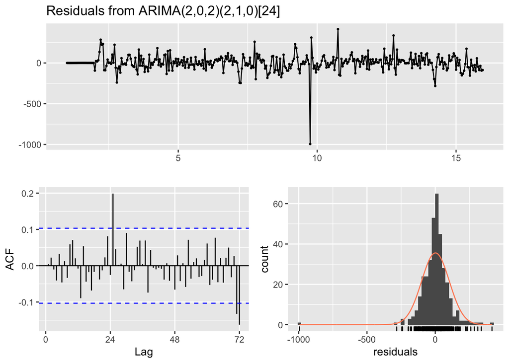

```
##
##  Ljung-Box test
##
## data:  Residuals from ARIMA(2,0,2)(2,1,0)[24]
## Q* = 49.401, df = 42, p-value = 0.2015
##
## Model df: 6.   Total lags used: 48
```

```r
checkresiduals(fit_hourofday)
```

```r
shapiro.test(fit_hourofday$residuals)
```

```
##
##  Shapiro-Wilk normality test
##
## data:  fit_hourofday$residuals
## W = 0.83265, p-value < 2.2e-16
```

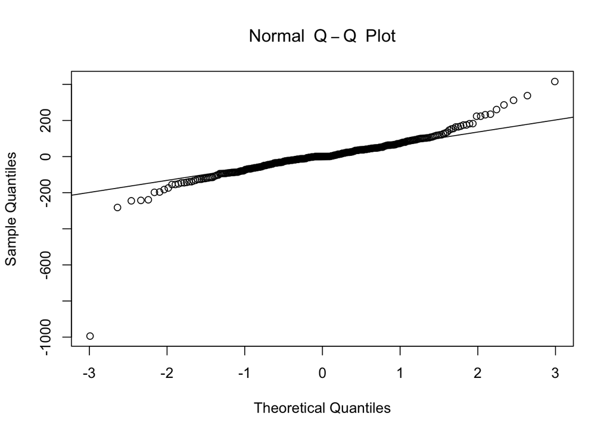

```r
qqnorm(fit_hourofday$residuals,main=expression(Normal~~Q-Q~~Plot))
qqline(fit_hourofday$residuals)
```

7. Use the 𝐴𝑅𝐼𝑀𝐴(𝑝,𝑑,𝑞)(𝑃,𝑄,𝐷)𝑠 model from Question 6 to forecast for July 1st (which is a Monday). Plot your result.

```r
predict_J01_hourofday <- forecast((fit_hourofday), h = 24)
predict_J01_hourofday
```

```
##          Point Forecast     Lo 80     Hi 80      Lo 95     Hi 95
## 16.00000       227.8331  91.94818  363.7179   20.01507  435.6510
## 16.04167       200.6664  16.08989  385.2429  -81.61901  482.9518
## 16.08333       171.3102 -31.19712  373.8175 -138.39801  481.0184
## 16.12500       225.7283  17.86634  433.5902  -92.16912  543.6257
## 16.16667       275.6225  67.03403  484.2109  -43.38603  594.6310
## 16.20833       474.0490 265.41085  682.6871  154.96450  793.1334
## 16.25000       694.6896 485.16432  904.2148  374.24836 1015.1308
## 16.29167       794.1640 582.82731 1005.5007  470.95243 1117.3756
## 16.33333       854.5382 640.96885 1068.1076  527.91205 1181.1644
## 16.37500       938.8870 723.20188 1154.5720  609.02511 1268.7488
## 16.41667      1030.5067 813.15384 1247.8596  698.09417 1362.9193
## 16.45833      1036.2899 817.81366 1254.7661  702.15935 1370.4204
## 16.50000      1025.3258 806.20510 1244.4466  690.20958 1360.4421
## 16.54167      1096.9451 877.51978 1316.3703  761.36306 1432.5271
## 16.58333      1095.5723 876.03954 1315.1051  759.82591 1431.3187
## 16.62500      1083.8175 864.26428 1303.3708  748.03980 1419.5953
## 16.66667      1139.2999 919.74664 1358.8532  803.52216 1475.0777
## 16.70833      1041.9611 822.39888 1261.5234  706.16964 1377.7526
## 16.75000      1030.5066 810.92097 1250.0923  694.67935 1366.3339
## 16.79167       888.2043 668.58663 1107.8219  552.32807 1224.0805
## 16.83333       755.7738 536.12371  975.4239  419.84798 1091.6996
## 16.87500       712.9892 493.31221  932.6663  377.02221 1048.9563
## 16.91667       615.5691 395.87305  835.2652  279.57297  951.5653
## 16.95833       477.2765 257.56894  696.9840  141.26281  813.2901
```

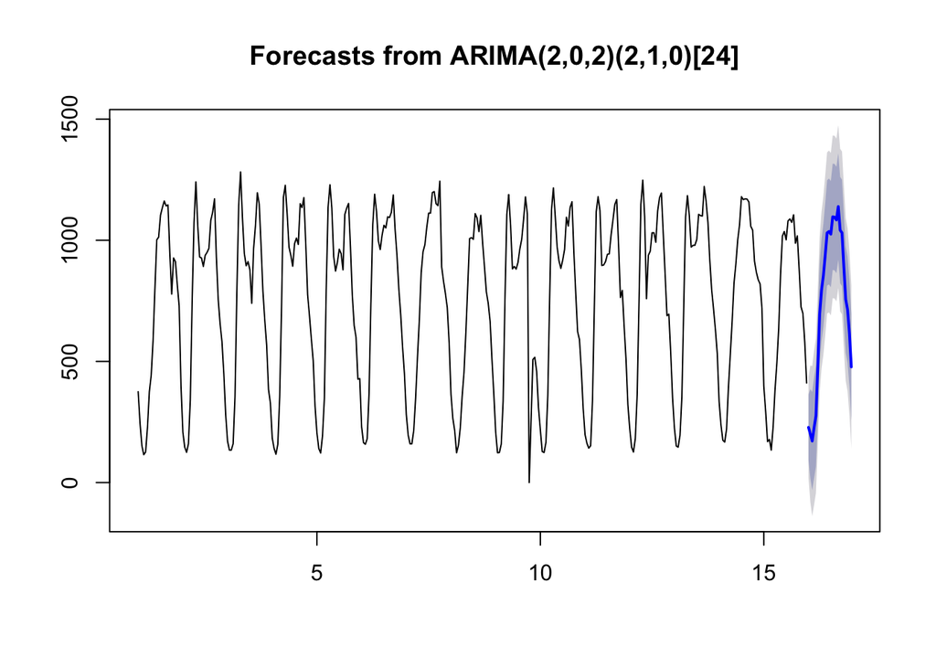

```r
plot(forecast(predict_J01_hourofday,h=24))
```

8. Compare the forecast of the models from Questions 5 and 7 for July 1 8:00, 9:00, 17:00 and 18:00, which model is better (Questions 4 or 6)?

```r
J01_8_dayofweek <- predict_J01_dayofweek$mean[8]
J01_9_dayofweek <- predict_J01_dayofweek$mean[9]
J01_17_dayofweek <- predict_J01_dayofweek$mean[17]
J01_18_dayofweek <- predict_J01_dayofweek$mean[18]

J01_8_hourofday <- predict_J01_hourofday$mean[8]
J01_9_hourofday <- predict_J01_hourofday$mean[9]
J01_17_hourofday <- predict_J01_hourofday$mean[17]
J01_18_hourofday <- predict_J01_hourofday$mean[18]

J01_8_real <- test[8]
J01_9_real <- test[9]
J01_17_real <- test[17]
J01_18_real <- test[18]

dayofweek_result <- c(J01_8_dayofweek,J01_9_dayofweek,J01_17_dayofweek,J01_18_dayofweek)
hourofday_result <- c(J01_8_hourofday,J01_9_hourofday,J01_17_hourofday,J01_18_hourofday)
real_result <- c(J01_8_real,J01_9_real,J01_17_real,J01_18_real)

df_compare <- data.frame(dayofweek_result, hourofday_result,real_result)

print (df_compare)
```

```
##   dayofweek_result hourofday_result real_result
## 1         1205.979         794.1640        1233
## 2         1080.979         854.5382        1110
## 3         1196.979        1139.2999        1142
## 4         1125.979        1041.9611        1129
```

```r
error_dayofweek <- real_result - dayofweek_result
error_hourofday <- real_result - hourofday_result

df_error <- data.frame(error_dayofweek, error_hourofday)
print (df_error)
```

```
##   error_dayofweek error_hourofday
## 1       27.021445       438.83601
## 2       29.021445       255.46175
## 3      -54.978555         2.70009
## 4        3.021445        87.03887
```

```r
SSE_dayofweek <- sum(error_dayofweek^2)
SSE_hourofday <- sum(error_hourofday^2)

df_SSE <- data.frame(SSE_dayofweek, SSE_hourofday)
print (df_SSE)
```

```
##   SSE_dayofweek SSE_hourofday
## 1      4604.173      265420.8
```

From the results above, we notice that the SSE for question 4 is much lower than that of question 6. That means we should choose the question 4’s model, which is a day of the week seasonal arima model.